# CS5702 W2 Worksheet Notebook

## 1.7 Multivariate analysis

Here we start exploring the relation ships between more than one variable.

For example, is there any relationship between `Background` [UG course] and choice of MSc?

```r
# This is an example of a 2-d table of frequencies.
table(surveyDF$Background, surveyDF$MSc)
```

```
##
##                                                             AI Apprenticeship
##    Life Sciences Bsc                                         0              0
##   Arts BA, CIM level 6 diploma marketing                     0              1
##   Biomedical Science                                         0              0
##   BSc Physics , MBA Business                                 0              0
##   Business analytics:operational research and risk analysis  0              0
##   Business studies                                           0              0
##   Computer and communication                                 0              0
##   Computer science                                          11              0
##   Economics                                                  0              0
##   Economics                                                  0              0
##   Engineering                                                5              0
##   Humanities e.g., geography or history                      0              1
##   ICT and MM                                                 0              0
##   Life Sciences BSc                                          0              0
##   Maths                                                      0              0
##   Media                                                      0              0
##   Natural sciences e.g. chemistry or biology                 0              0
##   Pharmacy                                                   0              0
##   Physics                                                    1              0
##   Physics & Philosophy                                       0              1
##   Statistics                                                 0              0
##
##                                                             Digital and Technology Degree Apprenticehsip
##    Life Sciences Bsc                                                                                   0
##   Arts BA, CIM level 6 diploma marketing                                                               0
##   Biomedical Science                                                                                   0
##   BSc Physics , MBA Business                                                                           0
##   Business analytics:operational research and risk analysis                                            0
##   Business studies                                                                                     0
##   Computer and communication                                                                           0
##   Computer science                                                                                     1
##   Economics                                                                                            0
##   Economics                                                                                            0
##   Engineering                                                                                          0
##   Humanities e.g., geography or history                                                                0
##   ICT and MM                                                                                           0
##   Life Sciences BSc                                                                                    0
##   Maths                                                                                                0
```

[output cut: 14 more lines]

```
##   Computer and communication                                  1
##   Computer science                                           20
##   Economics                                                   1
##   Economics                                                   1
##   Engineering                                                 6
##   Humanities e.g., geography or history                       0
##   ICT and MM                                                  1
##   Life Sciences BSc                                           1
##   Maths                                                       5
##   Media                                                       1
##   Natural sciences e.g. chemistry or biology                  4
##   Pharmacy                                                    1
##   Physics                                                     0
##   Physics & Philosophy                                        0
##   Statistics                                                  2
```

```r
# and if we want marginal totals wrap table() with the addmargins() function
addmargins(table(surveyDF$Background, surveyDF$MSc))
```

```
##
##                                                             AI Apprenticeship
##    Life Sciences Bsc                                         0              0
##   Arts BA, CIM level 6 diploma marketing                     0              1
##   Biomedical Science                                         0              0
##   BSc Physics , MBA Business                                 0              0
##   Business analytics:operational research and risk analysis  0              0
##   Business studies                                           0              0
##   Computer and communication                                 0              0
##   Computer science                                          11              0
##   Economics                                                  0              0
##   Economics                                                  0              0
##   Engineering                                                5              0
##   Humanities e.g., geography or history                      0              1
##   ICT and MM                                                 0              0
##   Life Sciences BSc                                          0              0
##   Maths                                                      0              0
##   Media                                                      0              0
##   Natural sciences e.g. chemistry or biology                 0              0
##   Pharmacy                                                   0              0
##   Physics                                                    1              0
##   Physics & Philosophy                                       0              1
##   Statistics                                                 0              0
##   Sum                                                       17              3
##
##                                                             Digital and Technology Degree Apprenticehsip
##    Life Sciences Bsc                                                                                   0
##   Arts BA, CIM level 6 diploma marketing                                                               0
##   Biomedical Science                                                                                   0
##   BSc Physics , MBA Business                                                                           0
##   Business analytics:operational research and risk analysis                                            0
##   Business studies                                                                                     0
##   Computer and communication                                                                           0
##   Computer science                                                                                     1
##   Economics                                                                                            0
##   Economics                                                                                            0
##   Engineering                                                                                          0
##   Humanities e.g., geography or history                                                                0
##   ICT and MM                                                                                           0
##   Life Sciences BSc                                                                                    0
```

[output cut: 17 more lines]

```
##   Computer science                                           20  32
##   Economics                                                   1   1
##   Economics                                                   1   1
##   Engineering                                                 6  11
##   Humanities e.g., geography or history                       0   1
##   ICT and MM                                                  1   1
##   Life Sciences BSc                                           1   1
##   Maths                                                       5   5
##   Media                                                       1   1
##   Natural sciences e.g. chemistry or biology                  4   4
##   Pharmacy                                                    1   1
##   Physics                                                     0   1
##   Physics & Philosophy                                        0   1
##   Statistics                                                  2   2
##   Sum                                                        55  76
```

```r
# and if you want proportions then wrap with prop.table()
prop.table(table(surveyDF$Background, surveyDF$MSc))
```

```
##
##                                                                     AI
##    Life Sciences Bsc                                        0.00000000
##   Arts BA, CIM level 6 diploma marketing                    0.00000000
##   Biomedical Science                                        0.00000000
##   BSc Physics , MBA Business                                0.00000000
##   Business analytics:operational research and risk analysis 0.00000000
##   Business studies                                          0.00000000
##   Computer and communication                                0.00000000
##   Computer science                                          0.14473684
##   Economics                                                 0.00000000
##   Economics                                                 0.00000000
##   Engineering                                               0.06578947
##   Humanities e.g., geography or history                     0.00000000
##   ICT and MM                                                0.00000000
##   Life Sciences BSc                                         0.00000000
##   Maths                                                     0.00000000
##   Media                                                     0.00000000
##   Natural sciences e.g. chemistry or biology                0.00000000
##   Pharmacy                                                  0.00000000
##   Physics                                                   0.01315789
##   Physics & Philosophy                                      0.00000000
##   Statistics                                                0.00000000
##
##                                                             Apprenticeship
##    Life Sciences Bsc                                            0.00000000
##   Arts BA, CIM level 6 diploma marketing                        0.01315789
##   Biomedical Science                                            0.00000000
##   BSc Physics , MBA Business                                    0.00000000
##   Business analytics:operational research and risk analysis     0.00000000
##   Business studies                                              0.00000000
##   Computer and communication                                    0.00000000
##   Computer science                                              0.00000000
##   Economics                                                     0.00000000
##   Economics                                                     0.00000000
##   Engineering                                                   0.00000000
##   Humanities e.g., geography or history                         0.01315789
##   ICT and MM                                                    0.00000000
##   Life Sciences BSc                                             0.00000000
##   Maths                                                         0.00000000
```

[output cut: 37 more lines]

```
##   Computer and communication                                0.01315789
##   Computer science                                          0.26315789
##   Economics                                                 0.01315789
##   Economics                                                 0.01315789
##   Engineering                                               0.07894737
##   Humanities e.g., geography or history                     0.00000000
##   ICT and MM                                                0.01315789
##   Life Sciences BSc                                         0.01315789
##   Maths                                                     0.06578947
##   Media                                                     0.01315789
##   Natural sciences e.g. chemistry or biology                0.05263158
##   Pharmacy                                                  0.01315789
##   Physics                                                   0.00000000
##   Physics & Philosophy                                      0.00000000
##   Statistics                                                0.02631579
```

**Extension Exercise 1.9:** Do AI and DSA students have different perceived levels of statistical and programming understanding?

To answer this question having turned `MSc` into a **factor** is now useful. In R a factor has a special meaning, i.e., a character variable which takes on a limited number of different values (these are often referred to as categorical variables) e.g., StudyMode and MSc, whilst Concern would be a problematic choice because the text content is essentially unbounded. To make this change of type we use the `as.factor()` function.

A common way to visualise the distribution of values for a variable is a **boxplot**. Boxplots can be used to compare distributions graphically based on five pieces of information, the minimum, Q1, Q2, Q3 and the maximum (they were proposed by the statistician John Tukey, see [wikipedia](https://en.wikipedia.org/wiki/Box_plot)).

In R we can use the boxplot() function to produce boxplots.

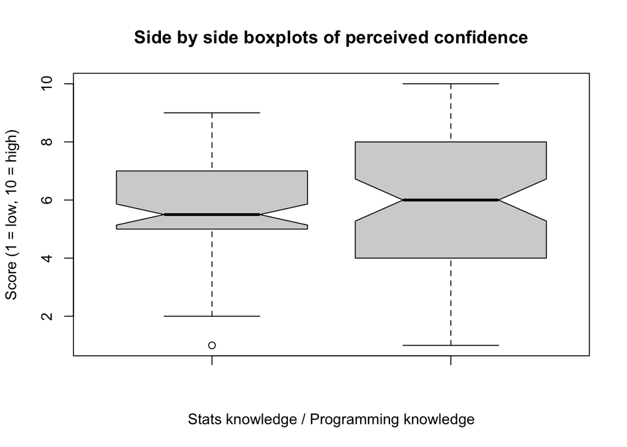

```r
# We can use boxplots to show similar(ish) information to histograms
# for example ...
boxplot(surveyDF$StatsKnowl, surveyDF$ProgKnowl,
        xlab = "Stats knowledge / Programming knowledge",
        ylab = "Score (1 = low, 10 = high)",
        notch = TRUE,  # This shows the 95% CI for the medians
        main = "Side by side boxplots of perceived confidence"
        )
```

Where we want to separate and compare the data by category e.g., MSc we can use a factor. We tell R how to do this by using a tilde:

`<variable_name> ~ <factor_name>`